```r
library(DESeq2)
```

```r
library(fgsea)
library(ggplot2)
library(msigdbr)
library(dplyr)
```

1. Output the R workflow you use for the analysis from raw data to generating differential expression results.

```r
countData <- read.delim(
  "Data/row_count_data.nodup.txt",
  header = TRUE,
  row.names = 1
)




SampleData <- read.delim(
  "Data/sample_groups.txt",
  header = TRUE,
  row.names = 1
)





SampleData$Group <- factor(SampleData$Group,levels = c("Normal", "Tumour"))

SampleData$Patient <- factor(SampleData$Patient)


dds <- DESeqDataSetFromMatrix(
  countData = countData,
  colData   = SampleData,
  design    = ~ Patient + Group
)

dds
```

```
## class: DESeqDataSet
## dim: 19701 10
## metadata(1): version
## assays(1): counts
## rownames(19701): CHAC1 GLRX ... G3BP1 RPS18
## rowData names(0):
## colnames(10): S02_Normal S03_Normal ... S06_Tumour S10_Tumour
## colData names(2): Group Patient
```

```r
keep <- rowSums(counts(dds) >= 10) >= 3
dds <- dds[keep, ]

dds <- DESeq(dds)
res <- results(dds)
```

2. Generate a boxplot of normalised gene expression across the 10 samples (e.g., boxplot (your normalised matrix), one plot with all 10 boxplots together, each representing one sample), and a PCA or MDS plot of the 10 samples together. (3 points)

```r
norm.counts <- counts(dds, normalized=TRUE)
head(norm.counts)
```

```
##        S02_Normal  S03_Normal  S05_Normal S06_Normal S10_Normal S02_Tumour
## CHAC1     0.00000    1.967789   0.8141814    0.00000   18.36860   56.58998
## GLRX    543.21062 1316.450740 359.8681874  168.55277  720.80900  106.89218
## MEFV     27.63426   25.581255   0.0000000   16.22433   36.73719   25.84974
## STXBP1   66.32223   84.614920  94.4450447  106.35950   76.64138  119.46773
## AKAP8L   21.31786   35.420199  21.9828983   40.56083   60.80638   18.16468
## AKR1C1   94.74604   47.226932  27.6821683   58.58786   65.24018  382.85564
##        S03_Tumour S05_Tumour S06_Tumour S10_Tumour
## CHAC1    7.146292   53.41811   52.94618   14.94332
## GLRX   184.782689   49.54724    0.00000  186.79154
## MEFV     0.000000   38.70878    0.00000   18.67915
## STXBP1  58.191233   68.90163   65.04817   74.71661
## AKAP8L   0.000000   31.74120    0.00000   29.88665
## AKR1C1  22.459774    0.00000    0.00000   16.18860
```

```r
vsd <- vst(dds, blind=FALSE)
head(assay(vsd),3)
```

```
##       S02_Normal S03_Normal S05_Normal S06_Normal S10_Normal S02_Tumour
## CHAC1   5.686640   5.968186   5.867909   5.686640   6.535890   7.137022
## GLRX    9.326630  10.469224   8.836285   8.030198   9.680511   7.617613
## MEFV    6.721091   6.683436   5.686640   6.486089   6.871495   6.688454
##       S03_Tumour S05_Tumour S06_Tumour S10_Tumour
## CHAC1   6.220971   7.098827   7.093028   6.454634
## GLRX    8.120286   7.050314   5.686640   8.131027
## MEFV    5.686640   6.901161   5.686640   6.542837
```

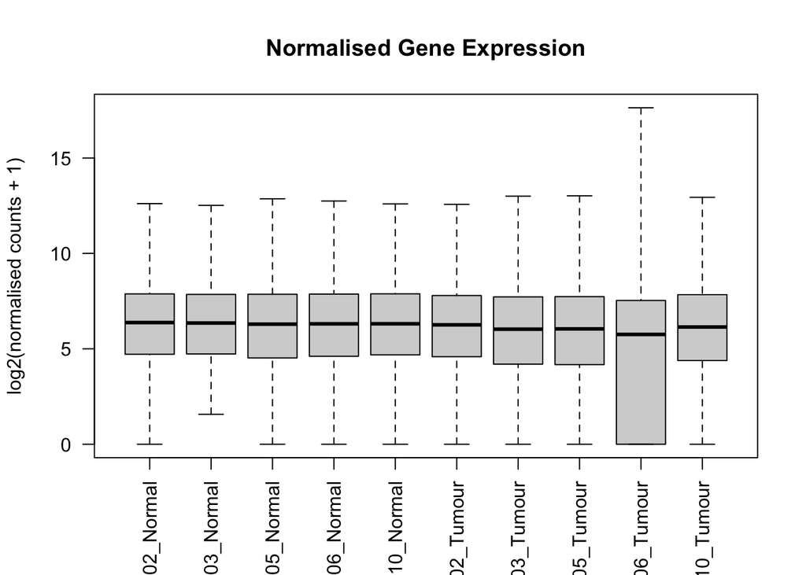

```r
boxplot(
  log2(norm.counts + 1),
  las = 2,
  outline = F,
  main = "Normalised Gene Expression",
  ylab = "log2(normalised counts + 1)"
)
```

```
## using ntop=500 top features by variance
```

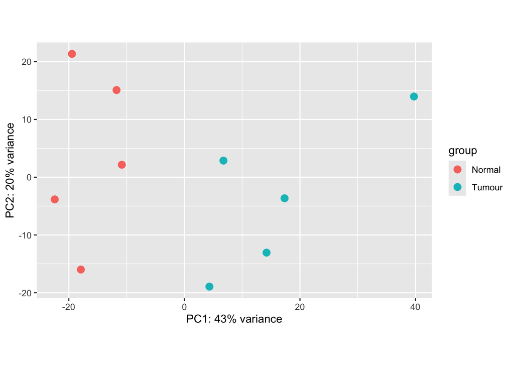

```r
plotPCA(vsd, intgroup = c("Group"))
```

3. List the top 10 mostly differentially expressed genes (based on adjusted p-values) between tumour and normal groups, with all their differential expression analysis statistics listed in one table.

```r
res <- results(dds, contrast = c("Group", "Tumour", "Normal"))


res_df <- as.data.frame(res)

# To make sure gene names have their own column:
res_df$Gene <- rownames(res_df)



# order the dataframe by adjusted P-value:
res_df <- res_df[!is.na(res_df$padj), ]
res_df <- res_df[order(res_df$padj), ]


top10_genes <- head(res_df,10)

top10_genes
```

```
##          baseMean log2FoldChange     lfcSE      stat       pvalue         padj
## SLC6A15  514.0347       3.740371 0.4068406  9.193702 3.795489e-20 5.004732e-16
## PTGS2    266.1026       4.262043 0.4941830  8.624422 6.441732e-18 2.831356e-14
## DAPL1    807.8465      -2.927431 0.3388200 -8.640079 5.617395e-18 2.831356e-14
## SPINK6   275.6194       7.771102 0.9107945  8.532223 1.435619e-17 4.732517e-14
## CLEC3B  2409.3374      -3.228985 0.3877862 -8.326716 8.311598e-17 2.191935e-13
## KRT15   1043.6316      -3.309828 0.4032286 -8.208315 2.243135e-16 4.929663e-13
## TNS4    5597.5364       1.911737 0.2544814  7.512285 5.810416e-14 1.094516e-10
## PI16     610.1234      -6.797063 0.9176225 -7.407254 1.289416e-13 2.125279e-10
## CST6     958.3939      -4.868265 0.6626807 -7.346321 2.037368e-13 2.984971e-10
## ITIH5    200.2914      -7.655044 1.0568594 -7.243200 4.382210e-13 4.877702e-10
##            Gene
## SLC6A15 SLC6A15
## PTGS2     PTGS2
## DAPL1     DAPL1
## SPINK6   SPINK6
## CLEC3B   CLEC3B
## KRT15     KRT15
## TNS4       TNS4
## PI16       PI16
## CST6       CST6
## ITIH5     ITIH5
```

4. Perform GSEA analysis against C5 GP BP gene sets (use the gene set file provided in RNA-seq practical) and list the top 10 mostly differentially regulated BP gene sets (based on adjusted p-values) with all the statistics listed in one table. (4 points)

```r
library(fgsea)
library(msigdbr)
library(dplyr)


go_bp <- msigdbr(
  species = "human",
  collection = "C5",
  subcollection = "BP"
)


pathways <- split(go_bp$gene_symbol, go_bp$gs_name)

# DESeq2 results
res <- results(dds, contrast = c("Group", "Tumour", "Normal"))

# ranking (EXACTLY like the coursework hint)
ranks <- res$stat
names(ranks) <- rownames(res)
ranks <- ranks[!is.na(ranks)]

# run fgsea
set.seed(1)
fg <- fgsea(
  pathways = pathways,
  stats    = ranks,
  minSize  = 15,
  maxSize  = 500
)

# top 10 BP pathways
fg <- fg[order(fg$padj), ]
top10.bp <- head(fg, 10)

top10.bp
```

```
##                                          pathway         pval         padj
##                                           <char>        <num>        <num>
##  1:            GOBP_FATTY_ACID_METABOLIC_PROCESS 1.635432e-17 5.920263e-14
##  2:   GOBP_MONOCARBOXYLIC_ACID_METABOLIC_PROCESS 1.040027e-16 1.882449e-13
##  3:                 GOBP_LIPID_CATABOLIC_PROCESS 2.460917e-12 2.969507e-09
##  4:               GOBP_ALCOHOL_METABOLIC_PROCESS 1.869423e-10 1.691828e-07
##  5:                 GOBP_AMIDE_METABOLIC_PROCESS 6.943193e-09 5.026872e-06
##  6: GOBP_FATTY_ACID_DERIVATIVE_METABOLIC_PROCESS 8.349405e-09 5.037474e-06
##  7:     GOBP_SMALL_MOLECULE_BIOSYNTHETIC_PROCESS 1.875130e-08 9.697100e-06
##  8:              GOBP_ACYL_COA_METABOLIC_PROCESS 3.040885e-08 1.376001e-05
##  9:          GOBP_TRIGLYCERIDE_METABOLIC_PROCESS 3.665732e-08 1.474439e-05
## 10:               GOBP_STEROID_METABOLIC_PROCESS 6.796391e-08 2.460294e-05
##       log2err         ES       NES  size  leadingEdge
##         <num>      <num>     <num> <int>       <list>
##  1: 1.0768682 -0.4834941 -2.214468   318 PTGDS, A....
##  2: 1.0574636 -0.4311037 -2.025360   489 ADH1B, P....
##  3: 0.8986712 -0.4557112 -2.058589   269 ADIPOQ, ....
##  4: 0.8266573 -0.4344953 -1.967362   274 ADH1B, D....
##  5: 0.7614608 -0.3877685 -1.786514   369 CMA1, GG....
##  6: 0.7477397 -0.5985407 -2.265063    69 TYRP1, G....
##  7: 0.7337620 -0.3646079 -1.707992   467 PTGDS, D....
##  8: 0.7195128 -0.5550379 -2.167412    81 ACSL1, H....
##  9: 0.7195128 -0.5486310 -2.135285    79 THRSP, C....
## 10: 0.7049757 -0.4234792 -1.885700   229 DAB2, MS....
```

5. Produce GESA enrichment plots for the top 2 mostly upregulated BP gene sets (based on adjusted p-values) in tumour compared to normal, and the top 2 mostly downregulated BP gene sets in tumour compared to normal. (3 points)

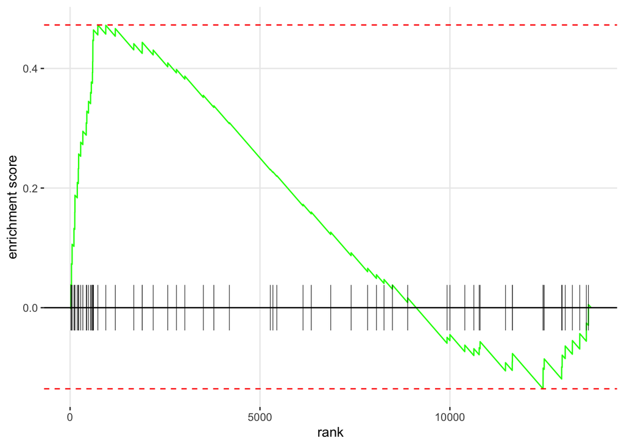

```r
# ensure fg is ordered
fg <- fg[order(fg$padj), ]

top2.up <- head(fg[fg$NES > 0, ], 2)
top2.down <- head(fg[fg$NES < 0, ], 2)

plotEnrichment(pathways[[top2.up$pathway[1]]], ranks)
```

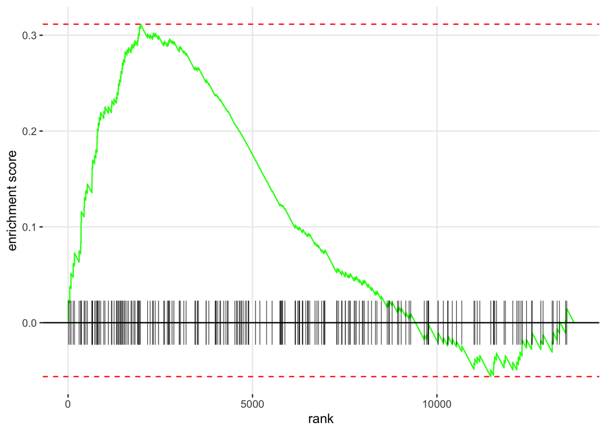

```r
plotEnrichment(pathways[[top2.up$pathway[2]]], ranks)
```

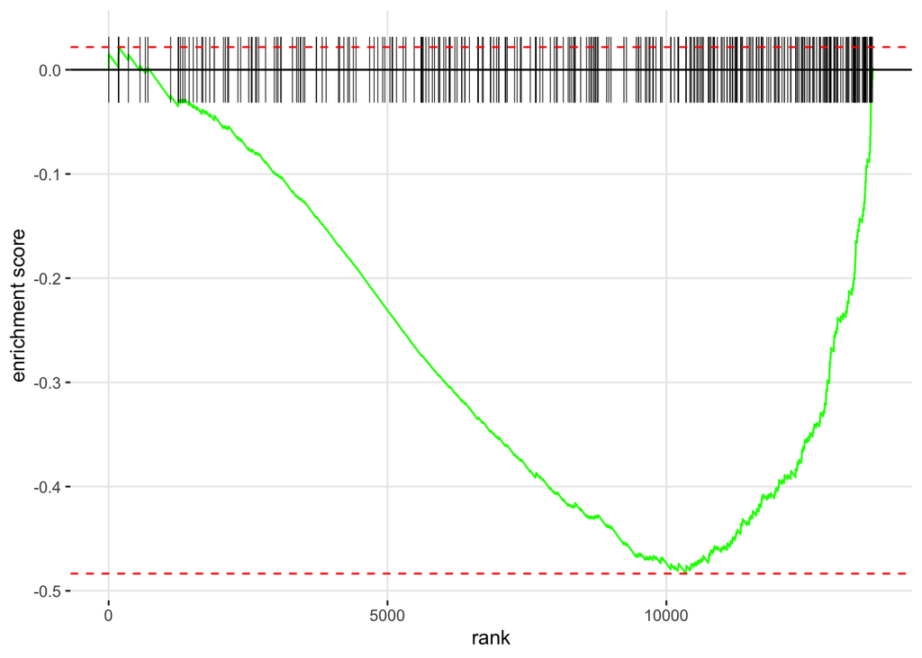

```r
plotEnrichment(pathways[[top2.down$pathway[1]]], ranks)
```

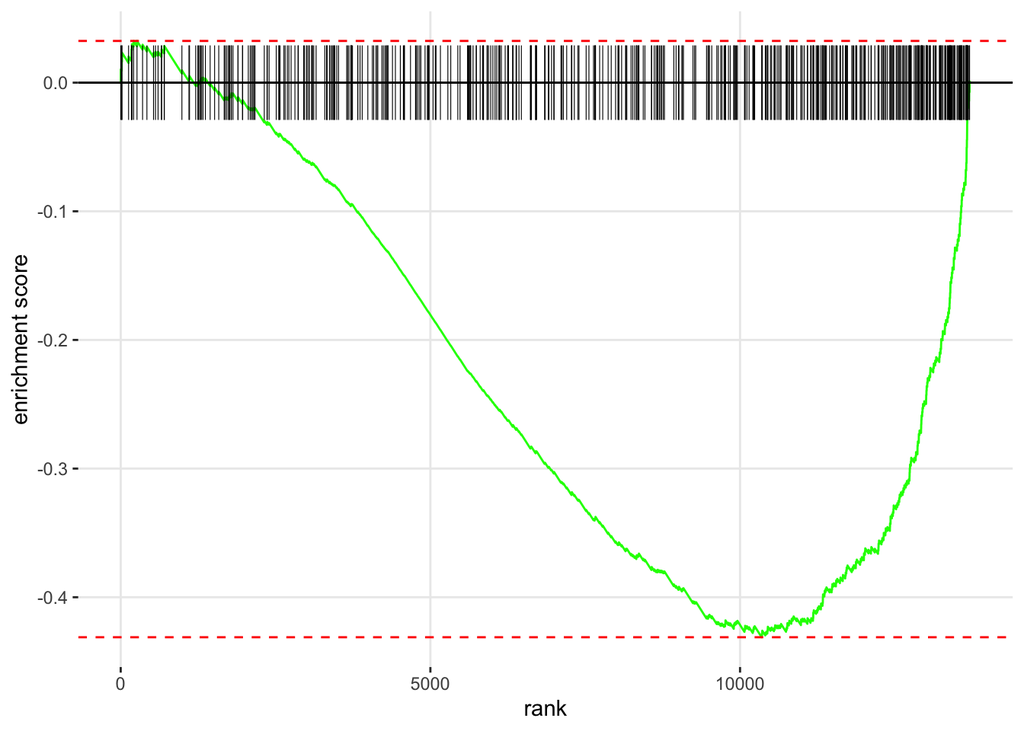

```r
plotEnrichment(pathways[[top2.down$pathway[2]]], ranks)
```